# Final Project: Metropolis-Hastings algorithm

Wen Yuan Yen

11/6/2018

# Metropolis-Hastings

## 1. Describe the algorithm

First, write a target function which returns density of beta(6,4)

$$\pi(x) = Beta(x:6,4)$$

Then do the following:

1. Initialize
   $$\phi_1 \sim Uni[0,1]$$
2. For t = 2,3,…,T, sample once from the proposal distribution as follows:
   $$\phi_t^{propose} \sim Q(x|\phi_{t-1})\equiv Beta\Big(x:c\phi_{t-1} ,c(1-\phi_{t-1}) \Big)$$
3. Compute acceptance probability at the current iteration as follows:
   $$A = \frac{\pi(\phi_t^{propose})Q(\phi_{t-1}|\phi_t^{propose})}{\pi(\phi_{t-1}) Q(\phi_t^{propose}|\phi_{t-1})}
   =\frac{\pi(\phi_t^{propose}) Beta\Big(\phi_{t-1}: c\phi_t^{propose} ,c(1-\phi_t^{propose}) \Big)}{ \pi(\phi_{t-1}) Beta\Big(\phi_t^{propose}:c\phi_{t-1} ,c(1-\phi_{t-1}) \Big)}$$
4. To accept the move with probabily min(1,A), we do
   $$\text{sample once} ~~~u \sim Uni[0,1]$$
   $$\text{if} ~u<A, ~\text{then set} ~~\phi_t \leftarrow \phi_t^{propose}.\text{(accept the proposal)}$$
   $$\text{if} ~u\ge A, ~\text{then set} ~~\phi_t \leftarrow \phi_{t-1}.\text{(reject the proposal)}$$
5. Loop for t = 2,3,…,T
6. Then we have

$$\{\phi_1,\phi_2,...,\phi_T\}$$

```r
target = function(x){
  if( x < 0 | x > 1 ){
    return(0)}
  else {
    density = 1 / beta(6,4) * (x)^5 * (1-x)^3
    return(density)
  }
}

sampler = function(c, iteration){
  phi = rep(0,iteration)
  phi[1] = runif(1)     #initialize; sample from uni(0,1)
  for(i in 2:iteration){
    current_phi = phi[i-1]
    proposed_phi = rbeta(1, c*current_phi,  c*(1-current_phi) )

    # compute acceptance probability
    Pr_current_to_proposed = target(current_phi) * dbeta(proposed_phi, c*current_phi, c*(1-current_phi))
    Pr_proposed_to_current = target(proposed_phi) * dbeta(current_phi, c*proposed_phi, c*(1-proposed_phi))
    A = Pr_proposed_to_current / Pr_current_to_proposed

    if(runif(1)<A){
      phi[i] = proposed_phi      # accept move with probabily min(1,A)
      } else {
        phi[i] = current_phi       # otherwise "reject" move, and stay where we are
      }
  }
  return(phi)
}
```

## 2. Evaluate the performance of the sampler

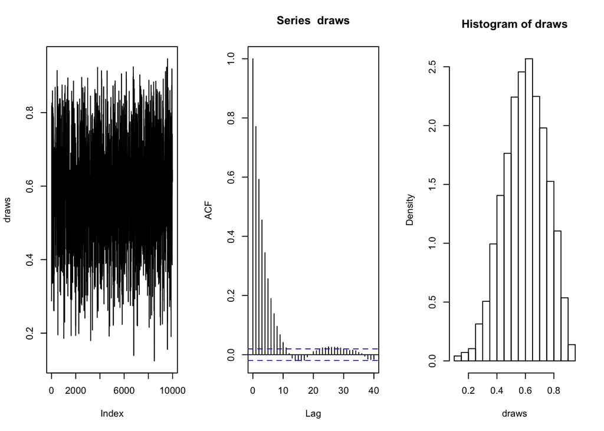

```r
set.seed(123)
draws = sampler(c = 1, 10000)  # set c = 1 and sample 10000

par(mfrow=c(1,3))  #1 row, 3 columns
plot(draws, type = 'l'); acf(draws); hist(draws, freq = FALSE)  #plot commands
```

## 3. Graphical comparison and KS statistic

### Histogram

Histogram of those draws fits closely to PDF of Beta(6,4) (red line).

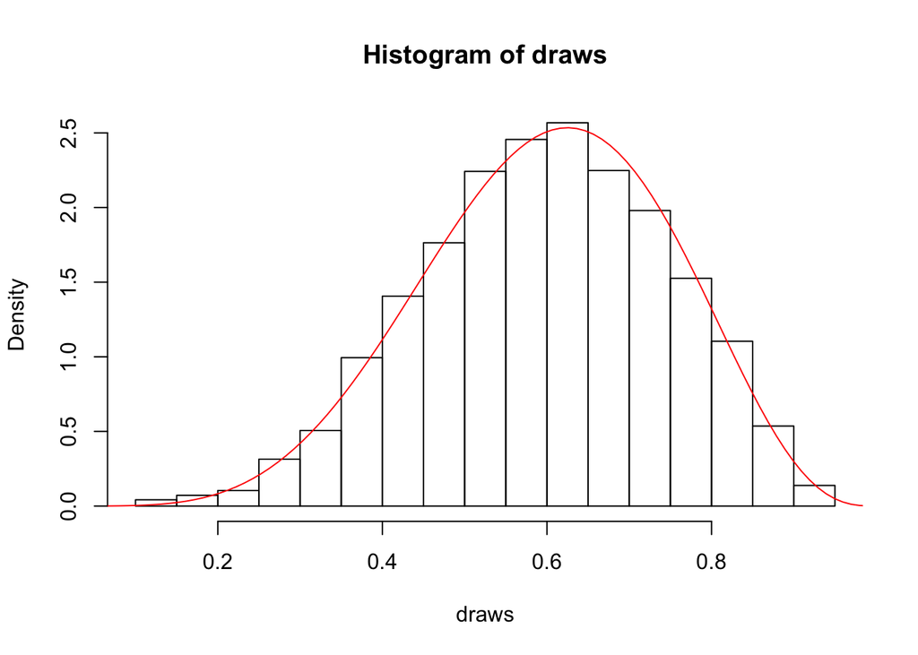

```r
p = seq(0,1, length=100)
hist(draws, freq = FALSE)
lines(p, dbeta(p, 6, 4), col=2)
```

### CDF and Kolmogorov-Smirnov test

Empirical CDF of those draws (black line) is close to CDF of Beta(6,4) (red line). However, when using Kolmogorov-Smirnov test, we reject the null and conclude that those 10000 draws are NOT from Beta(6,4), with significance level = 5%, p-value = 0.0005439, KS statistic = 0.0203.

$$H_{0}:\{\phi_t\} ~\text{comes from Beta(6,4)}$$
$$H_1: \{\phi_t\} ~\text{does NOT comes from Beta(6,4)}$$

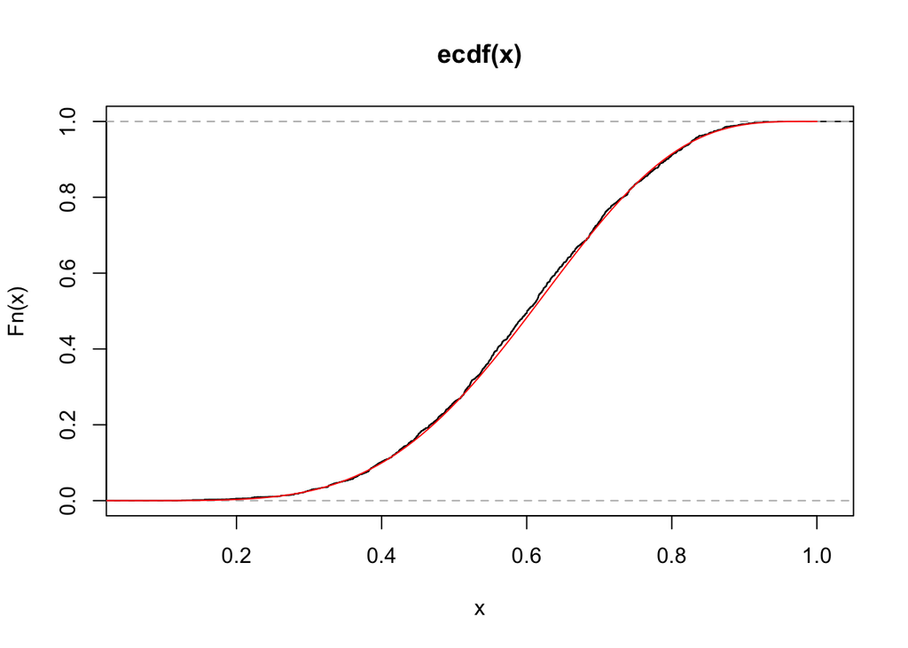

```r
plot.ecdf(draws)
lines(p,pbeta(p,6,4), col = 2)
```

```r
ks.test(draws, "pbeta", 6, 4)
```

```
##
##  One-sample Kolmogorov-Smirnov test
##
## data:  draws
## D = 0.020261, p-value = 0.0005439
## alternative hypothesis: two-sided
```

## 4. Re-run the sampler with c = 0.1, c = 2.5 and c = 10.

c = 2.5 is most effective at drawing from the target distribution. c = 0.1 behaves quite bad because it rejects too many proposals, as seen from the trace plot. c = 10 accepts too many proposals, as seen from the ACF plot, where acf are significant in many lags.

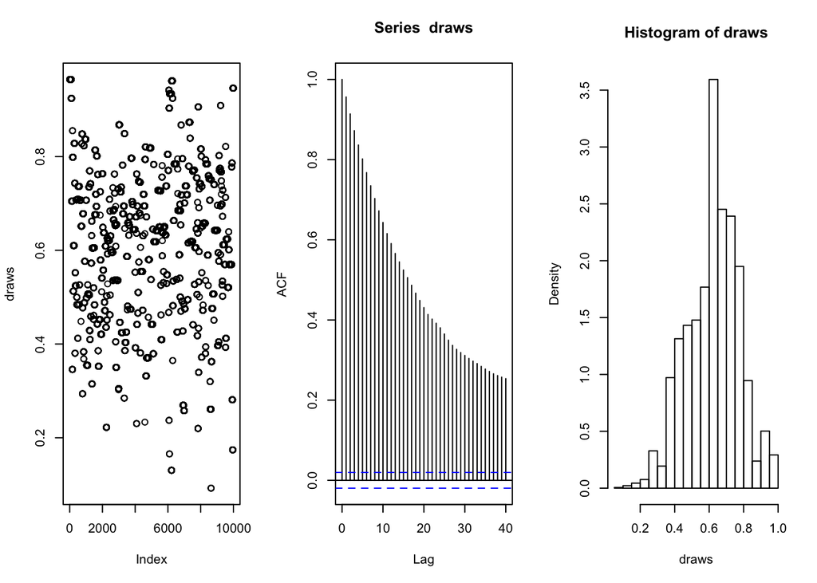

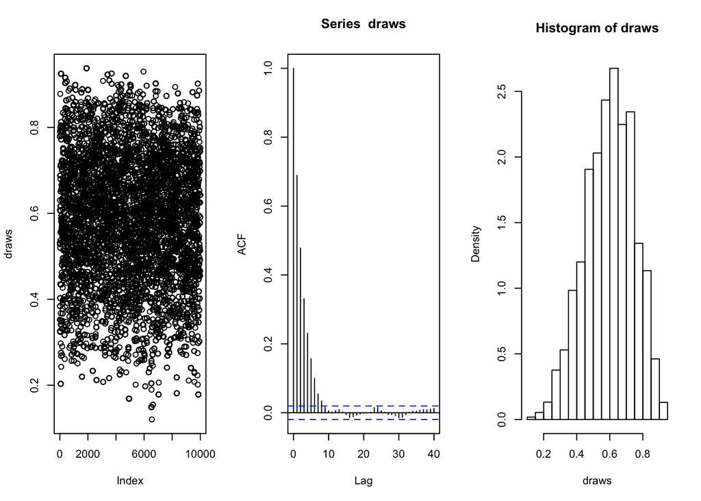

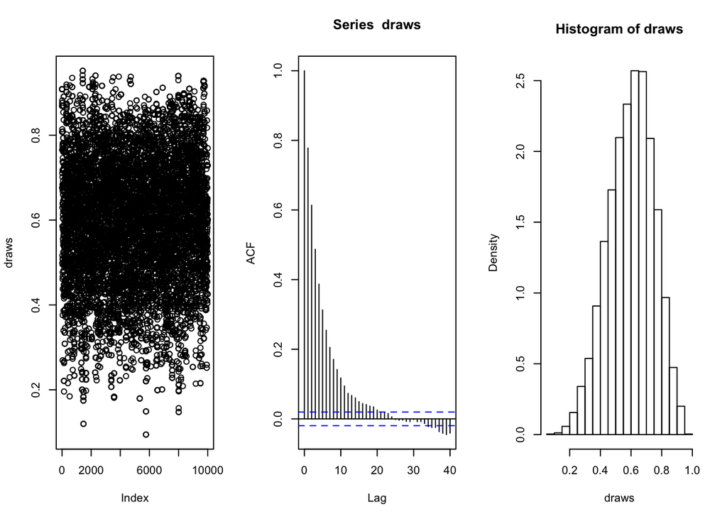

```r
c = c(0.1, 2.5, 10)
for(i in seq_along(c)){
  draws = sampler(c[i], 10000)
  par(mfrow=c(1,3))
  plot(draws); acf(draws); hist(draws, freq = FALSE)
}
```